# Real-World Machine Learning

Chapter 2

Paul Adamson

December 7, 2016

This file contains R code to accompany Chapter 2 of the book [“Real-World Machine Learning”](https://www.manning.com/books/real-world-machine-learning), by Henrik Brink, Joseph W. Richards, and Mark Fetherolf. The code was contributed by [Paul Adamson](http://github.com/padamson).

*NOTE: working directory should be set to this file’s location.*

## Listing 2.1 Convert categorical features to numerical binary features

Creating dummy variables in R is extremely easy with the `model.matrix` function. In the below code, when the `personData` dataframe is created, the `maritalstatus` variable is of type `factor` with levels “single” and “married” by default.

```r
personData <- data.frame(person = 1:2,
                         name = c("Jane Doe", "John Smith"),
                         age = c(24, 41),
                         income = c(81200, 121000),
                         maritalstatus = c("single","married"))
personDataNew <- data.frame(personData[,1:4],
                            model.matrix(~ maritalstatus - 1,
                                         data = personData))
str(personData)
```

```
## 'data.frame':    2 obs. of  5 variables:
##  $ person       : int  1 2
##  $ name         : Factor w/ 2 levels "Jane Doe","John Smith": 1 2
##  $ age          : num  24 41
##  $ income       : num  81200 121000
##  $ maritalstatus: Factor w/ 2 levels "married","single": 2 1
```

In the call to `model.matrix`, the −1 in the model formula ensures that we create a dummy variable for each of the two marital statuses (technically, it suppresses the creation of an intercept).

```r
model.matrix(~ maritalstatus - 1,
             data = personData)
```

```
##   maritalstatusmarried maritalstatussingle
## 1                    0                   1
## 2                    1                   0
## attr(,"assign")
## [1] 1 1
## attr(,"contrasts")
## attr(,"contrasts")$maritalstatus
## [1] "contr.treatment"
```

The matrix of dummy variables is then joined to the original dataframe (minus the maritalstatus column) with another call to `data.frame`.

## Listing 2.2 Simple feature extraction on Titanic cabins

The packages [`dplyr`](https://cran.rstudio.com/web/packages/dplyr) and [`tidyr`](https://cran.r-project.org/web/packages/tidyr) are excellent for tidying and preprocessing data, including creating new features from existing ones. (Note: `plyr` will be used later, but we must load it prior to `dplyr`.)

```r
titanic <- read.csv("../data/titanic.csv",
                    colClasses = c(
                      Survived = "factor",
                      Name = "character",
                      Ticket = "character",
                      Cabin = "character"))

titanic$Survived <- revalue(titanic$Survived, c("0"="no", "1"="yes"))

titanicNew <- titanic %>%
  separate(Cabin, into = "firstCabin", sep = " ", extra = "drop", remove = FALSE) %>%
  separate(firstCabin, into = c("cabinChar", "cabinNum"), sep = 1) %>%
  rowwise() %>%
  mutate(numCabins = length(unlist(strsplit(Cabin, " "))))

str(titanicNew)
```

```
## Classes 'rowwise_df', 'tbl_df', 'tbl' and 'data.frame':  891 obs. of  15 variables:
##  $ PassengerId: int  1 2 3 4 5 6 7 8 9 10 ...
##  $ Survived   : Factor w/ 2 levels "no","yes": 1 2 2 2 1 1 1 1 2 2 ...
##  $ Pclass     : int  3 1 3 1 3 3 1 3 3 2 ...
##  $ Name       : chr  "Braund, Mr. Owen Harris" "Cumings, Mrs. John Bradley (Florence Briggs Thayer)" "Heikkinen, Miss. Laina" "Futrelle, Mrs. Jacques Heath (Lily May Peel)" ...
##  $ Sex        : Factor w/ 2 levels "female","male": 2 1 1 1 2 2 2 2 1 1 ...
##  $ Age        : num  22 38 26 35 35 NA 54 2 27 14 ...
##  $ SibSp      : int  1 1 0 1 0 0 0 3 0 1 ...
##  $ Parch      : int  0 0 0 0 0 0 0 1 2 0 ...
##  $ Ticket     : chr  "A/5 21171" "PC 17599" "STON/O2. 3101282" "113803" ...
##  $ Fare       : num  7.25 71.28 7.92 53.1 8.05 ...
##  $ Cabin      : chr  "" "C85" "" "C123" ...
##  $ cabinChar  : chr  "" "C" "" "C" ...
##  $ cabinNum   : chr  "" "85" "" "123" ...
##  $ Embarked   : Factor w/ 4 levels "","C","Q","S": 4 2 4 4 4 3 4 4 4 2 ...
##  $ numCabins  : int  0 1 0 1 0 0 1 0 0 0 ...
```

In Listing 2.2, `read.csv` is used to read in the comma separated value (csv) data file. The `colClasses` argument is used to specify the correct class for some features. Then, the `revalue` function changes the levels of the `Survived` factor variable so that ‘0’ indicates ‘no’ and ‘1’ indicates ‘yes’. The `titanicNew` dataframe is then created by piping together `separate` from `tidyr` and `mutate` from `dplyr`. `separate` does exactly what its name implies: it separates a single character column into multiple columns. `mutate` is used to add a new feature often (as in this case) by acting on values of another feature.

## Listing 2.3 Feature normalization

The below code will normalize a feature using the “min-max” method. As an example, the `Age` feature of the `titanic` dataframe is normalized and a histogram of the new normalized feature is plotted with [`ggplot2`](http://docs.ggplot2.org/current/index.html#).

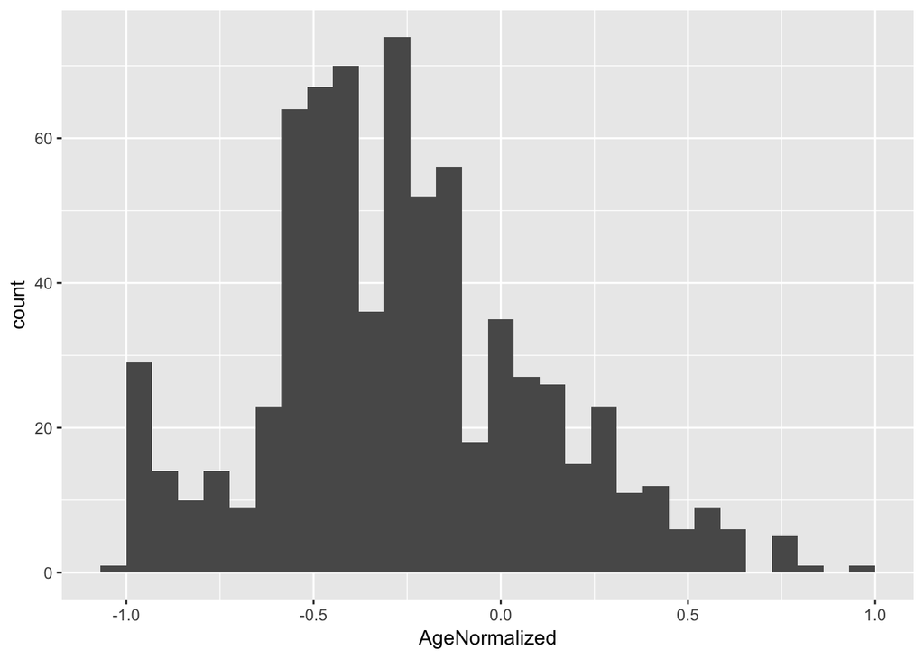

```r
normalizeFeature <- function(data, fMin=-1.0, fMax=1.0){
  dMin = min(na.omit(data))
  dMax = max(na.omit(data))
  factor = (fMax - fMin) / (dMax - dMin)
  normalized = fMin + (data - dMin)*factor
  normalized
}

titanic$AgeNormalized <- normalizeFeature(titanic$Age)
ggplot(data=titanic, aes(AgeNormalized)) +
  geom_histogram()
```

## Figure 2.12 Mosaic plot for Titanic data: Gender vs. survival

The [“Visualizing Categorical Data” (`vcd`)](https://cran.r-project.org/web/packages/vcd/vcd.pdf) package provides an excellent set of functions for exploring categorical data, including mosaic plots.

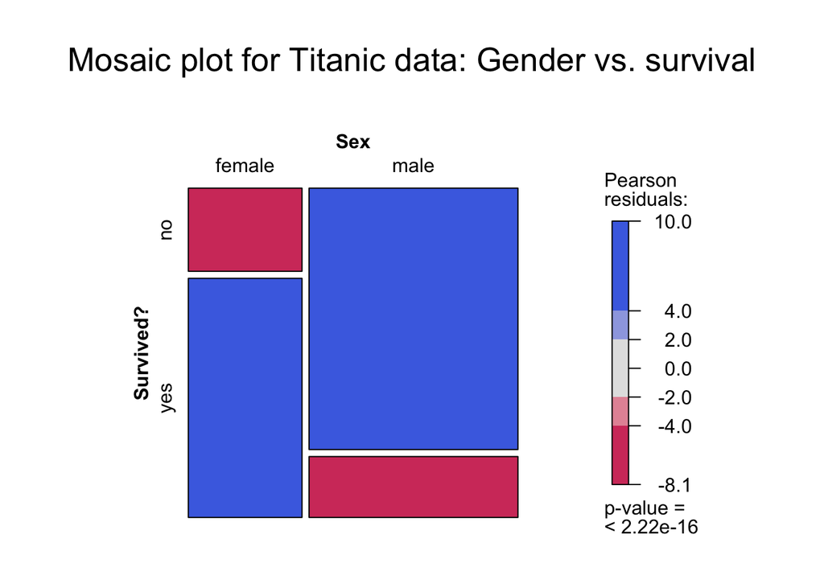

```r
mosaic(
  ~ Sex + Survived,
  data = titanic,
  main = "Mosaic plot for Titanic data: Gender vs. survival",
  shade = TRUE,
  split_vertical = TRUE,
  labeling_args = list(
    set_varnames = c(
      Survived = "Survived?")))
```

## Figure 2.13 Mosaic plot for Titanic data: Passenger class vs. survival

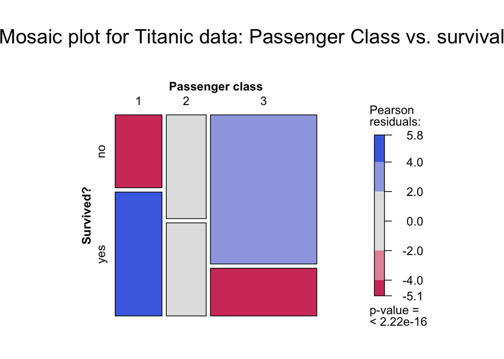

```r
mosaic(
  ~ Pclass + Survived,
  data = titanic,
  main = "Mosaic plot for Titanic data: Passenger Class vs. survival",
  shade = TRUE,
  split_vertical = TRUE,
  labeling_args = list(
    set_varnames = c(
      Pclass = "Passenger class",
      Survived = "Survived?")))
```

## Figure 2.14 Box plot for Titanic data: Passenger age vs. survival

The `boxplot` function is provided as part of the standard `graphics` package in R. `ggplot2` provides a much nicer version.

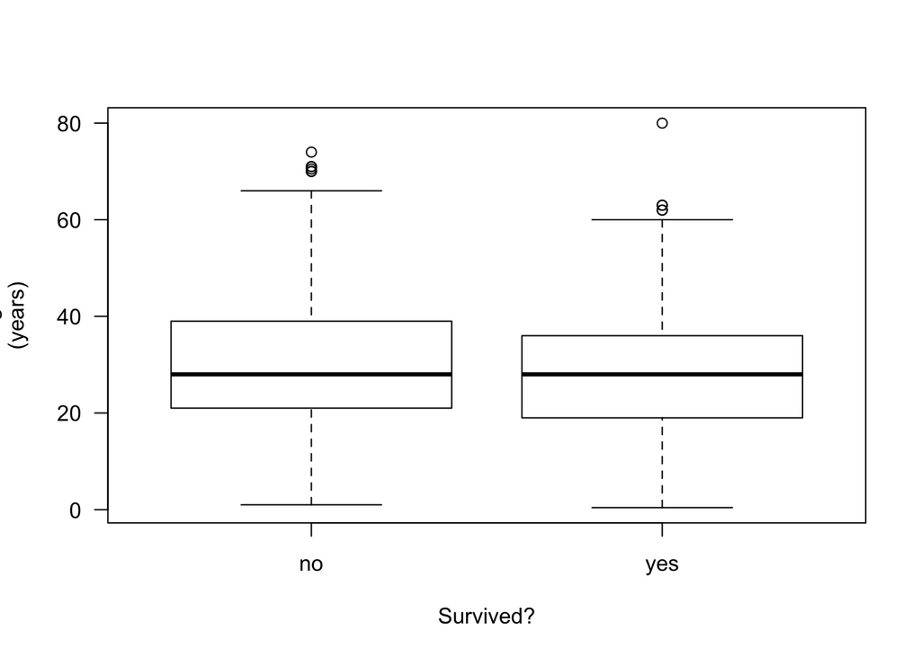

```r
boxplot(Age ~ Survived,
        data = titanic,
        xlab = "Survived?",
        ylab = "Age\n(years)",
        las = 1)
```

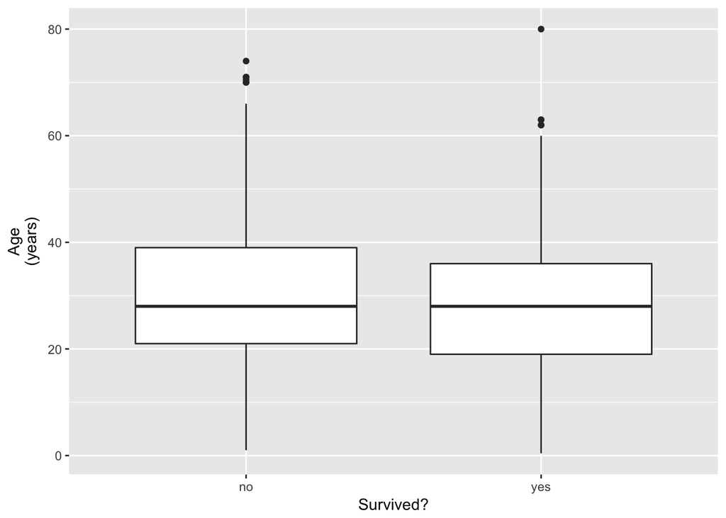

```r
ggplot(titanic, aes(Survived, Age)) +
  geom_boxplot() +
  xlab("Survived?") +
  ylab("Age\n(years)")
```

## Figure 2.15 Box plots for Titanic data: Passenger fare versus survival

Plots can be combined in rows and columns using the `mfrow` graphical parameter set via the `par` function. (Try `help(par)` to learn more.)

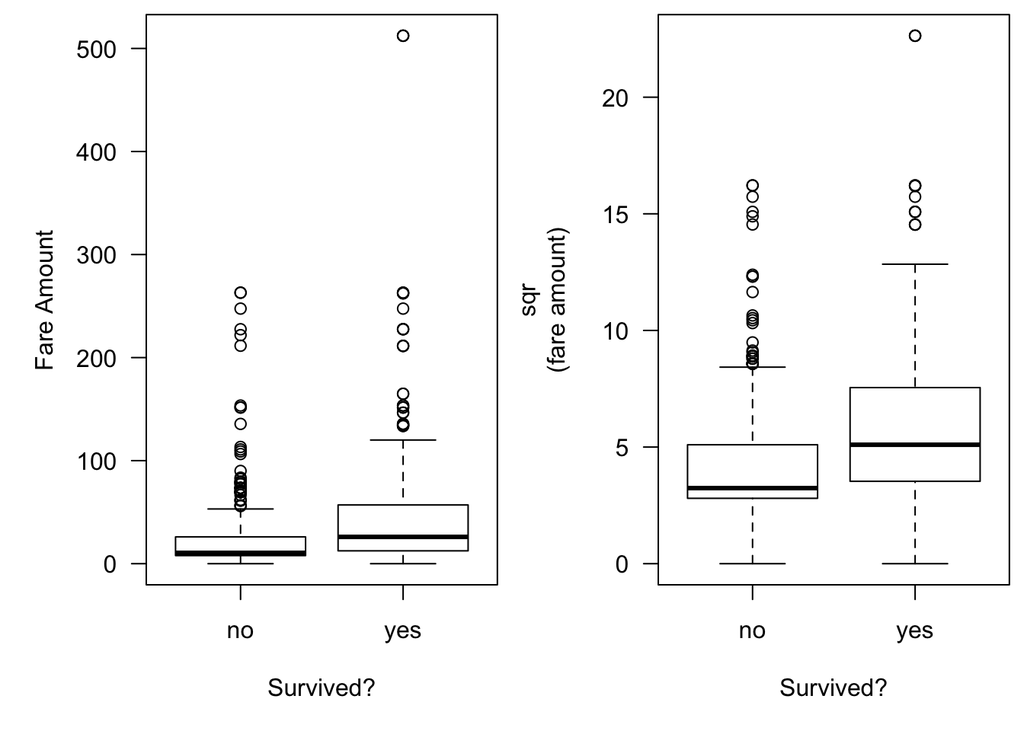

```r
par(mfrow=c(1,2))
par(mai=c(1,1,.1,.1), las = 1)
boxplot(Fare ~ Survived,
        data = titanic,
        xlab = "Survived?",
        ylab = "Fare Amount")
boxplot(Fare**(1/2) ~ Survived,
        data = titanic,
        xlab = "Survived?",
        ylab = "sqr\n(fare amount)")
```

## Figure 2.16 Density plot for MPG data, by region

The `sm.density.compare` function from the `sm` package is useful for comparing a set of univariate density estimates. The first argument is a vector of data, and the second argument is a vector of group labels that correspond to each value. The `colfill` variable and `legend` function are used to place a legend on the plot generated by `sm.density.compare`.

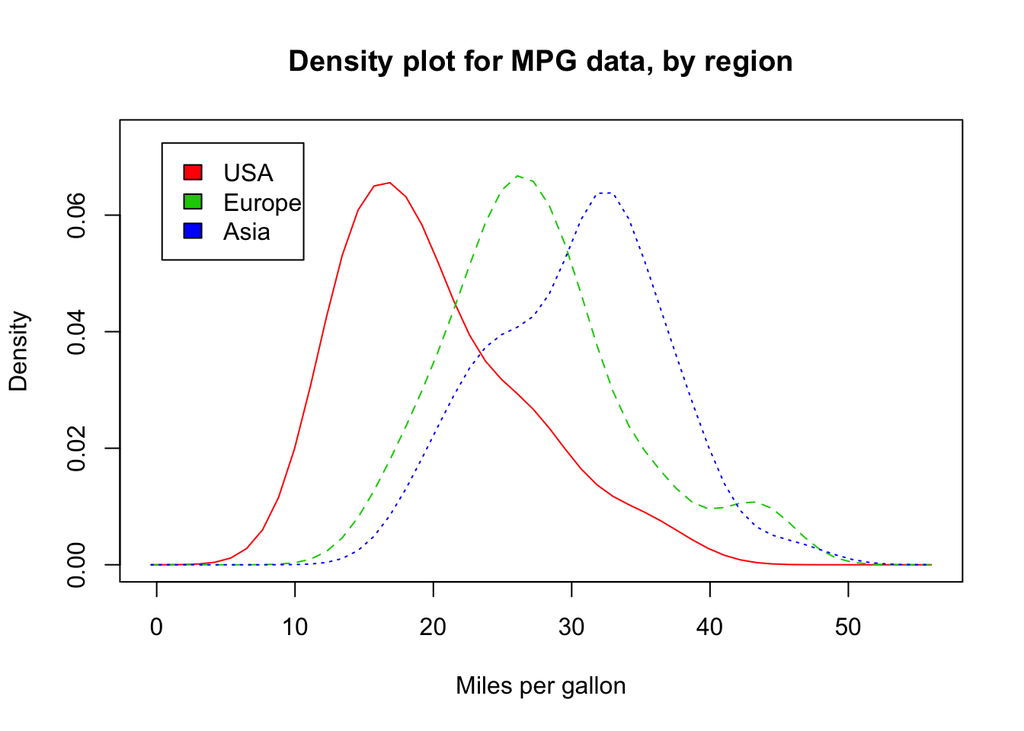

```r
par(mfrow=c(1,1))
auto <- read.csv("../data/auto-mpg.csv",
                 colClasses = c(origin = "factor"))

auto$origin <- revalue(auto$origin,
                       c("1\t"="USA", "2\t"="Europe", "3\t"="Asia"))

sm.density.compare(auto$mpg, auto$origin,
                   xlab="Miles per gallon",
                   ylab="Density")
title(main="Density plot for MPG data, by region")

colfill<-c(2:(2+length(levels(auto$origin))))
legend(x="topleft",
       inset=0.05,
       text.width=5,
       levels(auto$origin),
       fill=colfill)
```

## Figure 2.17 Scatterplots for MPG data

It doesn’t get much simpler than the `plot` function in R.

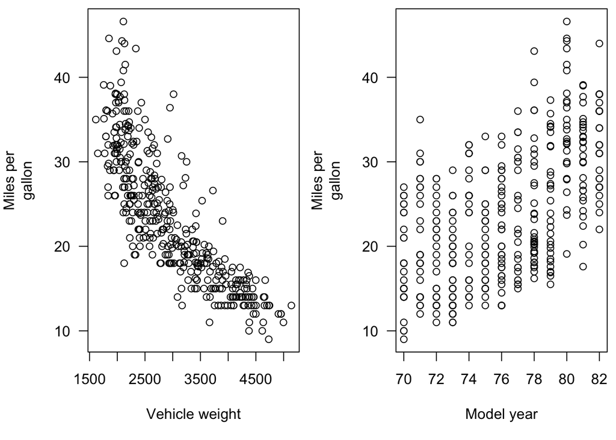

```r
par(mfrow=c(1,2), mai=c(1,1,.1,.1), las = 1)
plot(auto$weight, auto$mpg,
     xlab = "Vehicle weight",
     ylab = "Miles per\ngallon")
plot(auto$modelyear, auto$mpg,
     xlab = "Model year",
     ylab = "Miles per\ngallon")
```

Although not in the book, everyone should become familiar with facets via [`ggplot2`](http://docs.ggplot2.org/current/index.html#).

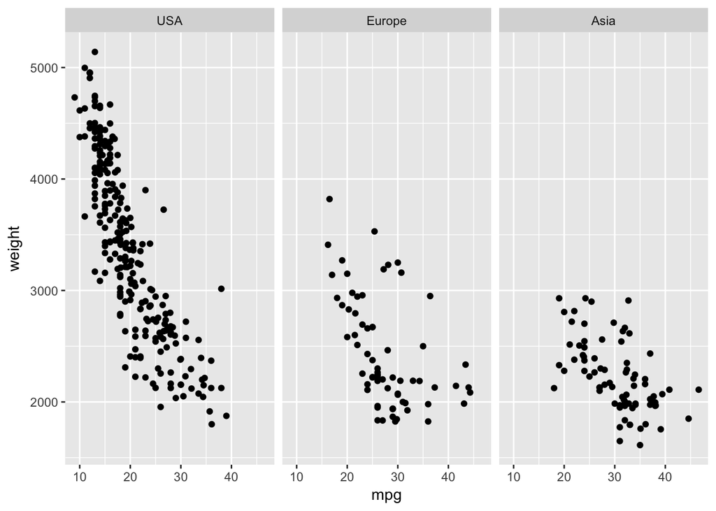

```r
p <- ggplot(auto, aes(mpg, weight)) +
  geom_point()
p + facet_grid(. ~ origin)
```